# Assignment 5

Angie Bouche, Tara Jagadeesh, Andrea Cheung

November 27, 2018

Load Tidyverse Etc

```r
library(tidyverse)
library(RColorBrewer)
library(kableExtra)
library(car)
library(reshape2)
library(stargazer)
library(scales)
read.csv("Doctoral_Salaries.csv")
```

```
##                                           Field Employment_Male
## 1   Agricultural sciences and natural resources          78,000
## 2            Biological and biomedical sciences          75,000
## 3                               Health sciences          75,000
## 4                                     Chemistry          80,000
## 5  Geosciences, atmospheric, and ocean sciences          75,167
## 6                         Physics and astronomy          95,000
## 7             Mathematics and computer sciences         105,000
## 8                                    Psychology          63,000
## 9                                     Economics         105,000
## 10                              Social sciences          64,000
## 11                                  Engineering          95,000
## 12                                    Education          71,000
## 13                          Humanities and arts          52,000
## 14       Business management and administration         123,500
```

[output cut: 17 more lines]

```r
read.csv("Faculty_Salaries.csv")
```

[output not shown]

[output cut: 781 more lines]

```r
enrollment <- read.csv("Grad_enrollment.csv")
read.csv("phd.csv")
```

[output not shown]

[output cut: 112 more lines]

# Part 1

#### Exploratory Scatterplot for Males and Females

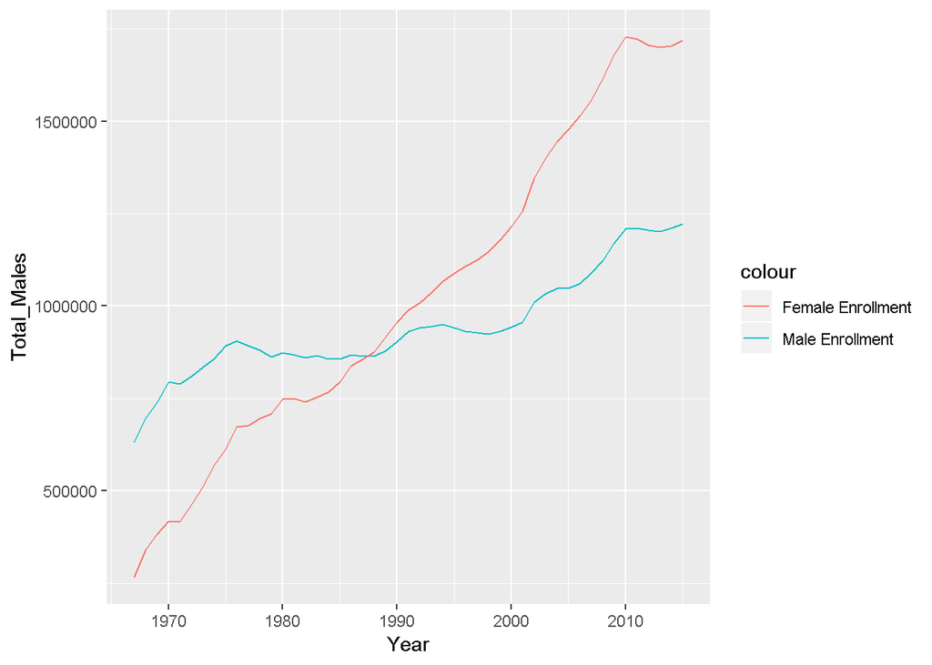

```r
enrollment_line <- ggplot(enrollment, aes(x=Year))+
  geom_line(aes(y=Total_Males, colour = "Male Enrollment"))+
  geom_line(aes(y=Total_Females, colour = "Female Enrollment"))
   #Scatterplot of female enrollment

enrollment_line
```

#### Linear Regression for Male and Female Enrollment

```r
menroll_model <- lm(Total_Males ~ Year, data = enrollment)
menroll_model
```

```
##
## Call:
## lm(formula = Total_Males ~ Year, data = enrollment)
##
## Coefficients:
## (Intercept)         Year
##   -17112153         9069
```

```r
#results in equation y = - 17112153 + 9069x

fenroll_model <- lm(Total_Females ~ Year, data = enrollment)
fenroll_model
```

```
##
## Call:
## lm(formula = Total_Females ~ Year, data = enrollment)
##
## Coefficients:
## (Intercept)         Year
##   -58955502        30126
```

```r
#results in equation y = - 58955502 + 30126x
```

##### Model Diagnostics, Fit and Significance

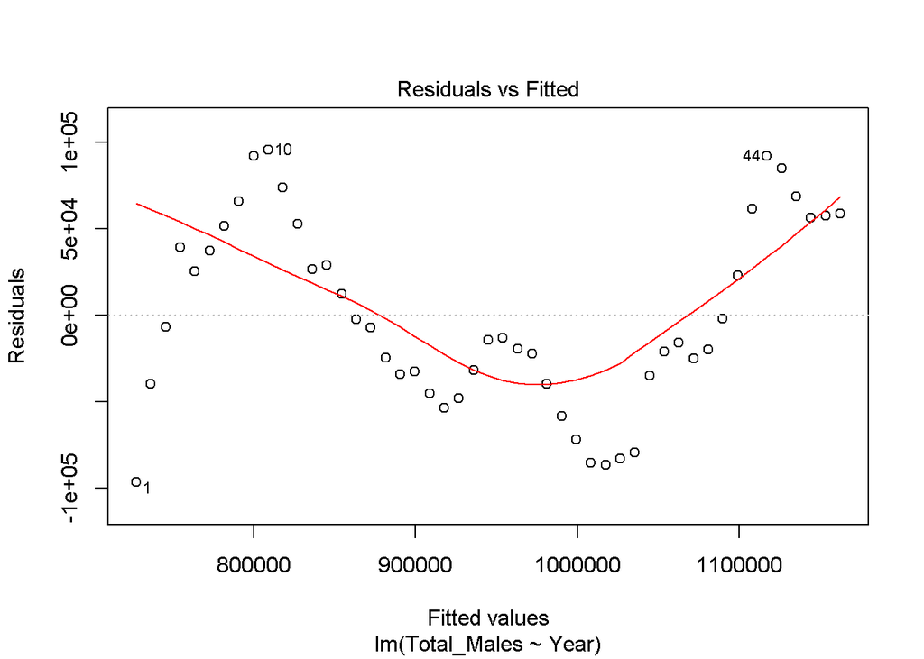

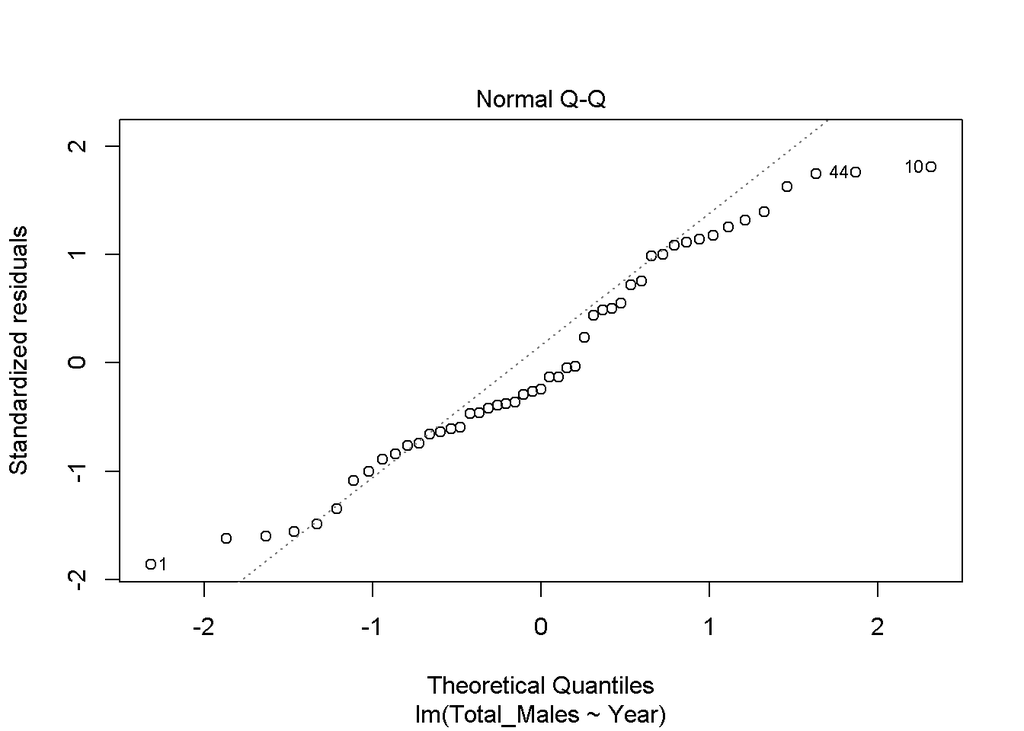

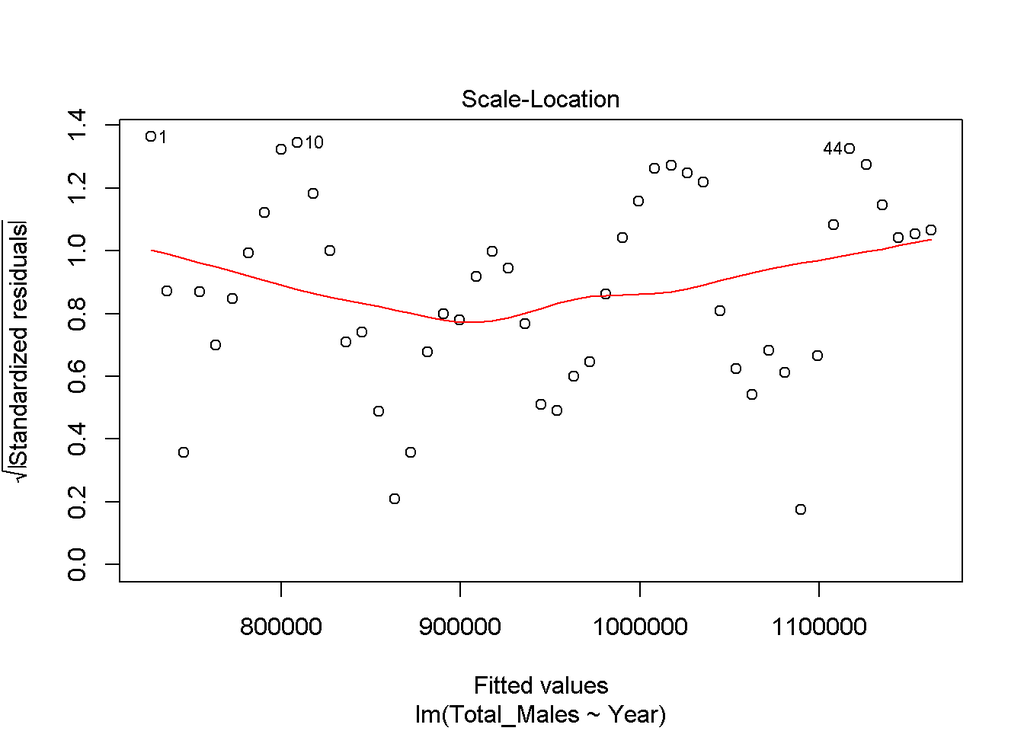

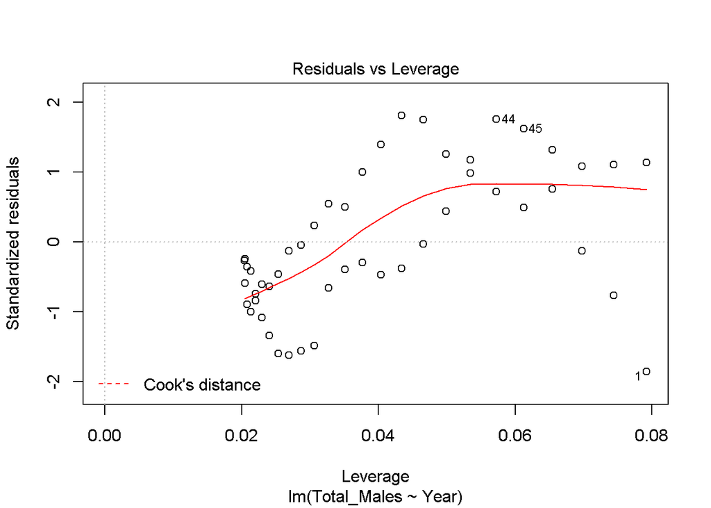

```r
plot(menroll_model)
```

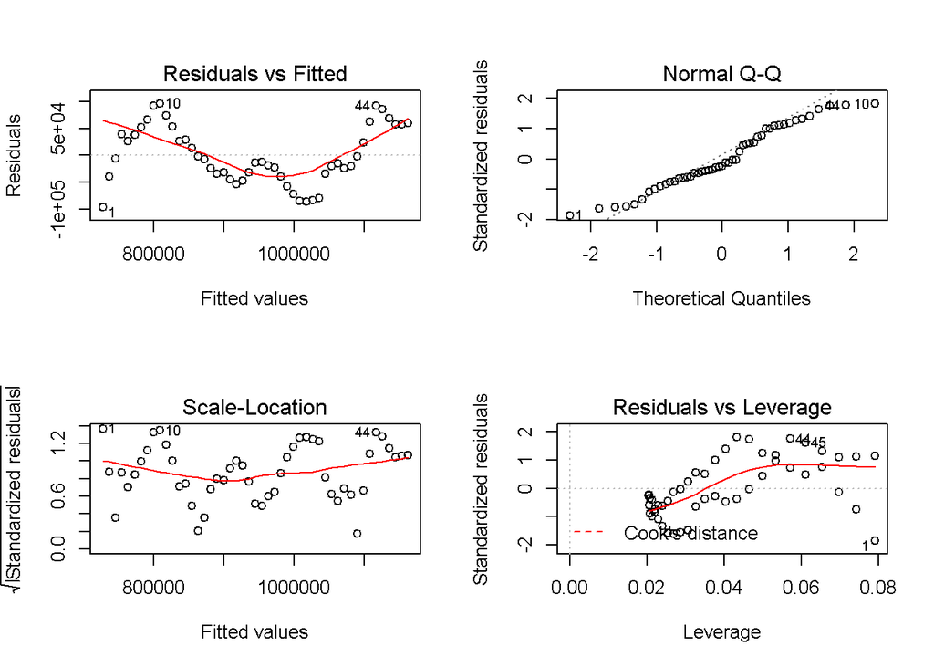

```r
par(mfrow = c(2,2))
plot(menroll_model)
```

```r
#Q-Q plot appears normally distributed, but there seems to be peaks that don't match up with the red line on Residuals vs. Fitted graph.

summary(menroll_model)
```

```
##
## Call:
## lm(formula = Total_Males ~ Year, data = enrollment)
##
## Residuals:
##    Min     1Q Median     3Q    Max
## -96461 -34861 -12841  51876  95766
##
## Coefficients:
##              Estimate Std. Error t value Pr(>|t|)
## (Intercept) -17112153    1087024  -15.74   <2e-16 ***
## Year             9069        546   16.61   <2e-16 ***
## ---
## Signif. codes:  0 '***' 0.001 '**' 0.01 '*' 0.05 '.' 0.1 ' ' 1
##
## Residual standard error: 54050 on 47 degrees of freedom
## Multiple R-squared:  0.8545, Adjusted R-squared:  0.8514
## F-statistic:   276 on 1 and 47 DF,  p-value: < 2.2e-16
```

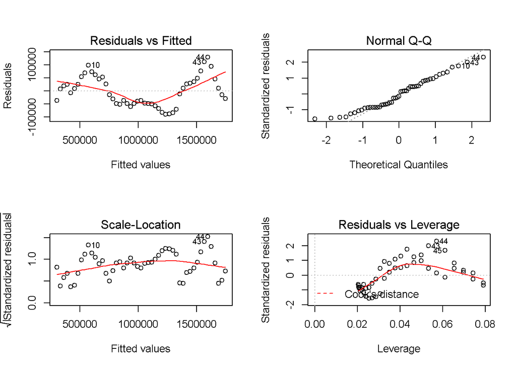

```r
#Multiple R-squared:  0.8545,   Adjusted R-squared:  0.8514
#F-statistic:   276 on 1 and 47 DF,  p-value: < 2.2e-16
#Standard error  1087024 and 546

plot(fenroll_model)
par(mfrow = c(2,2))
plot(fenroll_model)
```

```r
#Q-Q plot appears normally distributed, but there seems to be peaks that don't match up with the red line on Residuals vs. Fitted graph.

summary(fenroll_model)
```

```
##
## Call:
## lm(formula = Total_Females ~ Year, data = enrollment)
##
## Residuals:
##    Min     1Q Median     3Q    Max
## -89397 -48101  -7633  45267 129727
##
## Coefficients:
##               Estimate Std. Error t value Pr(>|t|)
## (Intercept) -5.896e+07  1.161e+06  -50.77   <2e-16 ***
## Year         3.013e+04  5.832e+02   51.66   <2e-16 ***
## ---
## Signif. codes:  0 '***' 0.001 '**' 0.01 '*' 0.05 '.' 0.1 ' ' 1
##
## Residual standard error: 57730 on 47 degrees of freedom
## Multiple R-squared:  0.9827, Adjusted R-squared:  0.9823
## F-statistic:  2669 on 1 and 47 DF,  p-value: < 2.2e-16
```

```r
#Multiple R-squared:  0.9827,   Adjusted R-squared:  0.9823
#F-statistic:  2669 on 1 and 47 DF,  p-value: < 2.2e-16
#Standard error 1161000 and 583.2
```

##### Finalized Graph for Male and Female Enrollment

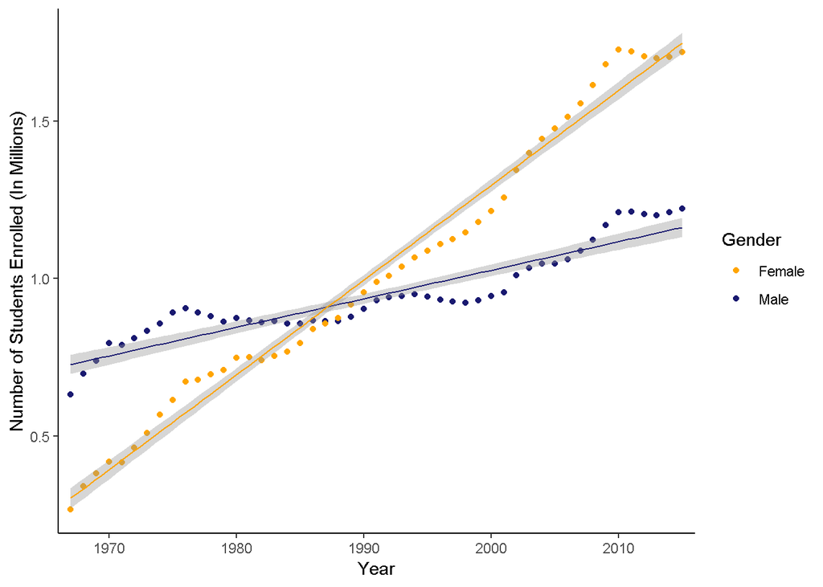

```r
enrollment_graph <- ggplot(enrollment, aes(x=Year))+
  geom_point(aes(y=Total_Males/1000000, color="Male"))+ #add cl smooth
  geom_point(aes(y = Total_Females/1000000, color="Female"))+
  geom_smooth(method = lm, se = TRUE, size = 0.5, color = "midnightblue",(aes(y=Total_Males/1000000)))+
  geom_smooth(method = lm, se = TRUE, size = 0.5, color = "orange1",(aes(y=Total_Females/1000000)))+
  theme_classic()+
  scale_x_continuous(expand= c(0,0), limits= c(1966,2016))+
  labs(x= "Year", y = "Number of Students Enrolled (In Millions)", color = "Gender")

enrollment_graph + scale_color_manual(values=c("orange1", "midnightblue"))
```

```r
#Pearsons R

male_pearson <- cor.test(enrollment$Year, enrollment$Total_Males)

male_pearson
```

```
##
##  Pearson's product-moment correlation
##
## data:  enrollment$Year and enrollment$Total_Males
## t = 16.612, df = 47, p-value < 2.2e-16
## alternative hypothesis: true correlation is not equal to 0
## 95 percent confidence interval:
##  0.8690777 0.9568547
## sample estimates:
##       cor
## 0.9243741
```

```r
female_pearson <- cor.test(enrollment$Year, enrollment$Total_Females)

female_pearson
```

```
##
##  Pearson's product-moment correlation
##
## data:  enrollment$Year and enrollment$Total_Females
## t = 51.659, df = 47, p-value < 2.2e-16
## alternative hypothesis: true correlation is not equal to 0
## 95 percent confidence interval:
##  0.9845609 0.9951144
## sample estimates:
##       cor
## 0.9913086
```

## Part 2

```r
#read csv file
phd <- read_csv("phd.csv")
ac_phd <- phd %>%
  filter(sex == "female") %>%
  filter(year != "1990") %>%
  filter(year != "1995") %>%
  filter(year != "2005") %>%
  filter(year != "2010") %>%
  filter(field != "all") %>%
  filter(field != "lifesci") %>%
  filter(field != "mathcomp") %>%
  filter(field != "other") %>%
  filter(field != "psychsoc") %>%
  select("field", "sex", "year", "number", "percent")

phd_prop <- ac_phd %>%
  select("field", "year", "number")

phd_dcast <- dcast(phd_prop, year~field) %>%
  select(-year)
rownames(phd_dcast) <- c("1985", "2000", "2015")

phd_proptable <- prop.table(as.matrix(phd_dcast),1)

female_phd_x2 <- chisq.test(phd_dcast)
female_phd_x2
```

```
##
##  Pearson's Chi-squared test
##
## data:  phd_dcast
## X-squared = 2073.3, df = 6, p-value < 2.2e-16
```

Pie chart for 1985

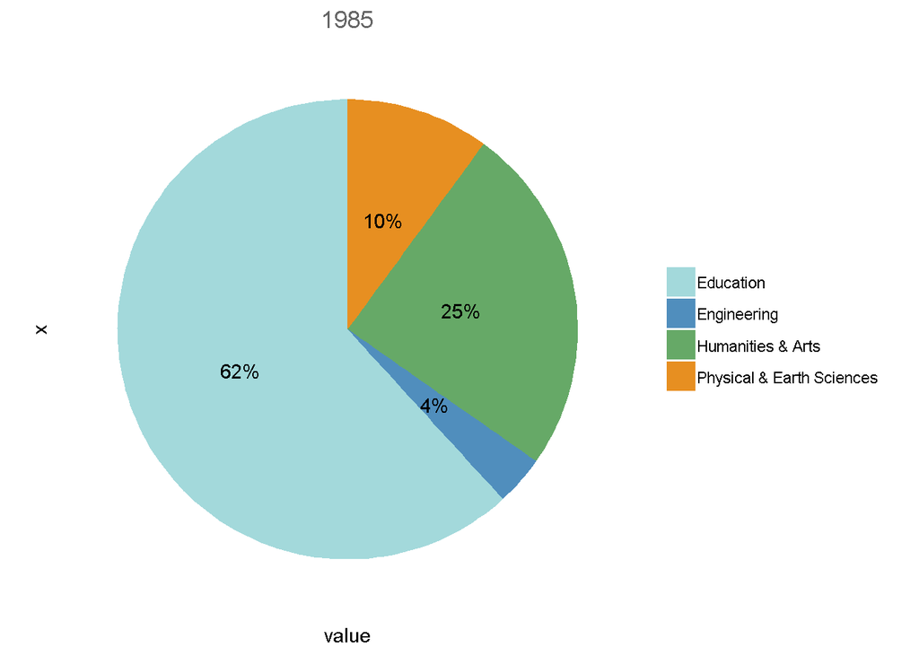

```r
dfpie1985 <- data.frame(
  group = c("Education", "Engineering", "Humanities & Arts", "Physical & Earth Sciences"),
  value = c(0.6178761, 0.03504425, 0.2463717, 0.1007080)
  )

pie1985 <- ggplot(dfpie1985, aes(x="", y=value, fill=group)) + geom_bar(stat="identity", width=1)


pie1985 = pie1985 + coord_polar("y", start=0) + geom_text(aes(label = paste0(round(value*100), "%")), position = position_stack(vjust = 0.5))

pie1985 = pie1985 + scale_fill_manual(values=c("#a3d9db", "#508EBD", "#66a967", "#e78f21", "#999999"))

pie1985 = pie1985 + theme_classic() +  theme(legend.title=element_blank())+ labs(title = "1985", align=c)+ theme(axis.line = element_blank(),
          axis.text = element_blank(),
          axis.ticks = element_blank(),
          plot.title = element_text(hjust = 0.5, color = "#666666"))

pie1985
```

Pie chart for 2000

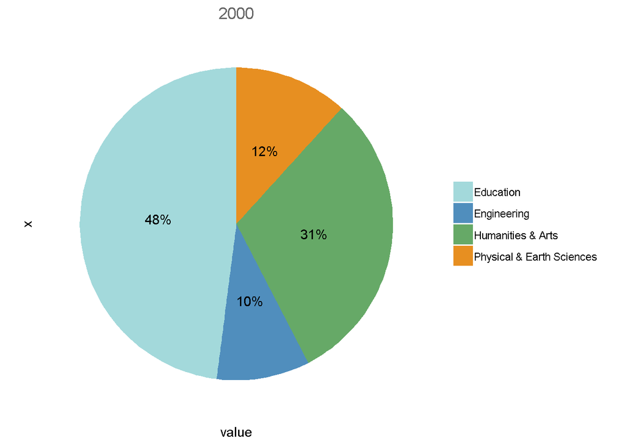

```r
dfpie2000 <- data.frame(
  group = c("Education", "Engineering", "Humanities & Arts", "Physical & Earth Sciences"),
  value = c(0.4797383, 0.09620021, 0.3067386, 0.1173229)
  )

pie2000 <- ggplot(dfpie2000, aes(x="", y=value, fill=group)) + geom_bar(stat="identity", width=1)


pie2000 = pie2000 + coord_polar("y", start=0) + geom_text(aes(label = paste0(round(value*100), "%")), position = position_stack(vjust = 0.5))

pie2000 = pie2000 + scale_fill_manual(values=c("#a3d9db", "#508EBD", "#66a967", "#e78f21", "#999999"))

pie2000 = pie2000 + theme_classic() +  theme(legend.title=element_blank())+ labs(title = "2000", align=c)+ theme(axis.line = element_blank(),
          axis.text = element_blank(),
          axis.ticks = element_blank(),
          plot.title = element_text(hjust = 0.5, color = "#666666"))

pie2000
```

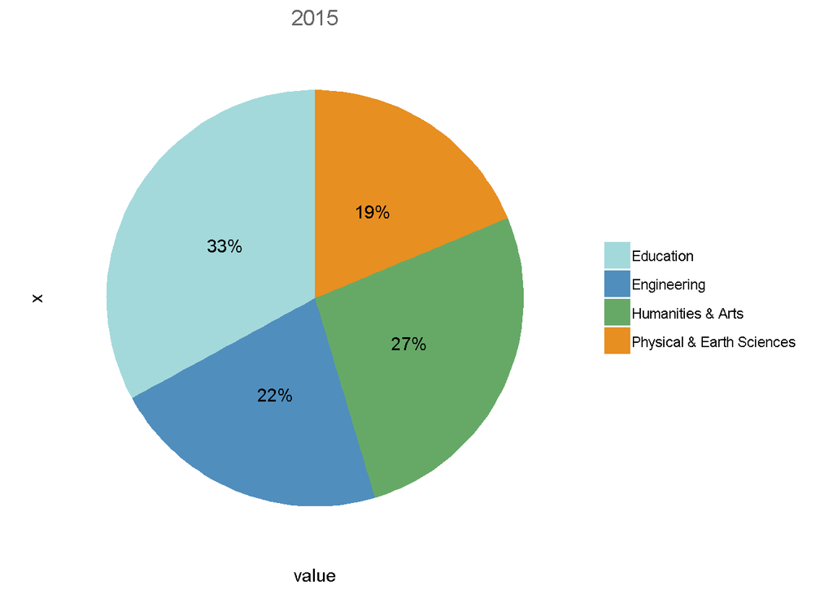

```r
dfpie2015 <- data.frame(
  group = c("Education", "Engineering", "Humanities & Arts", "Physical & Earth Sciences"),
  value = c(0.3296621, 0.21660548, 0.2665914, 0.1871411)
  )

pie2015 <- ggplot(dfpie2015, aes(x="", y=value, fill=group)) + geom_bar(stat="identity", width=1)


pie2015 = pie2015 + coord_polar("y", start=0) + geom_text(aes(label = paste0(round(value*100), "%")), position = position_stack(vjust = 0.5))

pie2015 = pie2015 + scale_fill_manual(values=c("#a3d9db", "#508EBD", "#66a967", "#e78f21", "#999999"))

pie2015 = pie2015 + theme_classic() +  theme(legend.title=element_blank())+ labs(title = "2015", align=c)+ theme(axis.line = element_blank(),
          axis.text = element_blank(),
          axis.ticks = element_blank(),
          plot.title = element_text(hjust = 0.5, color = "#666666"))

pie2015
```

# Part 3 - Male and female salaries for starting postdoctoral and other employment positions (2015)

Compare median salaries for male and female doctorate recipients in 2015. Answer these two questions:

Does median salary differ significantly between male and female starting postdoc positions? Does median salary differ significantly between male and female PhD recipients in non-postdoc employment positions?

Wilcoxon signed-rank - two sample paired

```r
doctoral <- read_csv("Doctoral_Salaries.csv")
```

## Data visualization - boxplots

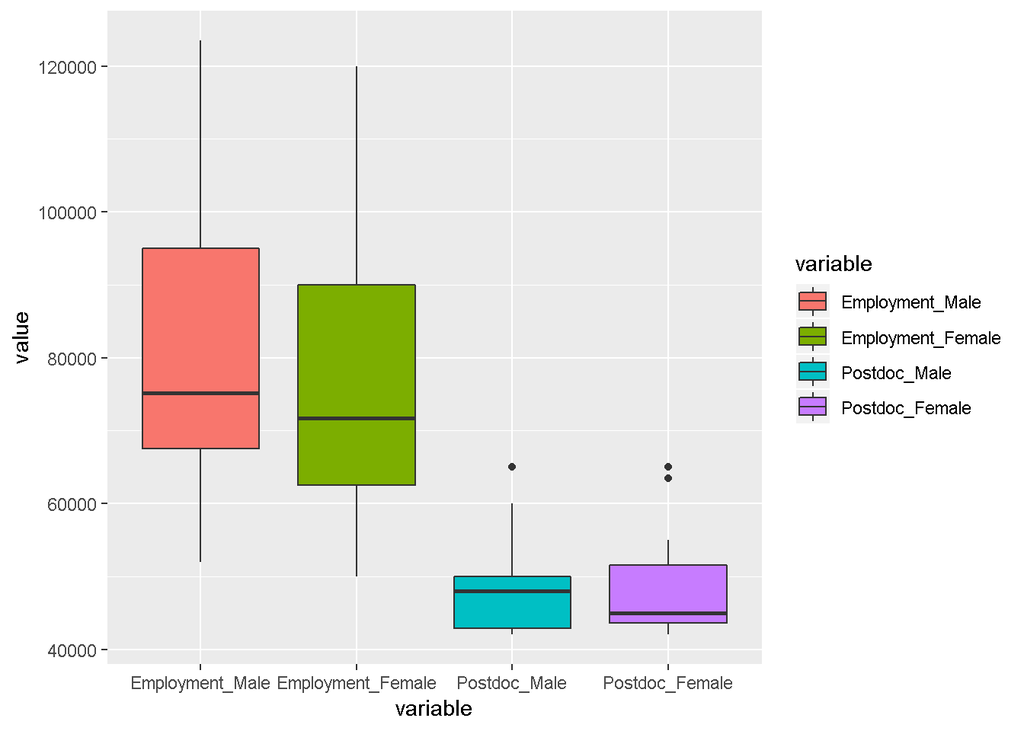

```r
doctoral_melt <- melt(doctoral[c('Field', 'Employment_Male', 'Employment_Female', 'Postdoc_Male', 'Postdoc_Female')],id.vars = 1)


employment_box <- ggplot(doctoral_melt, aes(x = variable, y = value, fill = variable))+
  geom_boxplot()
employment_box
```

## Wilcox rank test

```r
employment_wilcox <- wilcox.test(doctoral$Employment_Male, doctoral$Employment_Female, paired = TRUE)
employment_wilcox #V = 101, p-value = 0.002572
```

```
##
##  Wilcoxon signed rank test with continuity correction
##
## data:  doctoral$Employment_Male and doctoral$Employment_Female
## V = 101, p-value = 0.002572
## alternative hypothesis: true location shift is not equal to 0
```

```r
postdoc_wilcox <- wilcox.test(doctoral$Postdoc_Male, doctoral$Postdoc_Female, paired = TRUE)
postdoc_wilcox #V = 19.5, p-value = 0.8884
```

```
##
##  Wilcoxon signed rank test with continuity correction
##
## data:  doctoral$Postdoc_Male and doctoral$Postdoc_Female
## V = 19.5, p-value = 0.8884
## alternative hypothesis: true location shift is not equal to 0
```

# Part 4 - Multivariate linear regression

Exploring academic salaries for professors in U.S. colleges. Explore relationships between variables in the ‘Faculty salary data (2008 - 2009 survey)’ dataset. Develop a model describing faculty salary based on data for faculty sex, rank, years in current position, field, and number of years since doctoral degree was earned. You should make decisions regarding which variables should remain in your final model. Describe the results qualitatively and quantitatively (i.e., don’t just report the statistical results of the model – make sure you describe interesting findings in text). You can also discuss any concerns that you have with the model(s) you present, if any.

Dependent variable (y): faculty salary Possible predictor variables: faculty sex, rank, years in current position, field, and number of years since doctoral degree was earned

Steps: 1) Explore data - find means of salary, make density plot of salary by diff predictor variables 2) Make initial model 3) Test for colinearity 4) Refine model 3) Run diagnostic plots (to test Linearity, Independence, Homoscedasticity (residuals variance), Normality) 5) AIC to compare different models

## Make new dataframe

```r
faculty_salary <- read_csv("Faculty_Salaries.csv")
#Reorder columns
faculty_salary <- faculty_salary[c("Salary", "Discipline", "Sex", "Faculty_Rank", "Years_Since_PhD", "Years_Faculty_Service")]
```

## Explore data

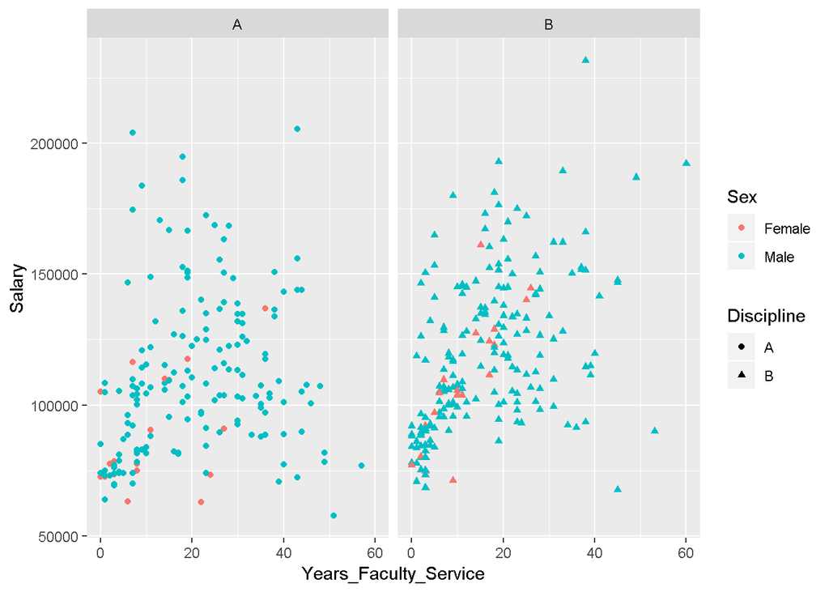

```r
#Salary means by Sex
sex_mean <- faculty_salary %>%
  group_by(Sex) %>%
  summarize(
    mean = mean(Salary)
  )

#Salary means by Discipline
discipline_mean <- faculty_salary %>%
  group_by(Discipline) %>%
  summarize(
    mean = mean(Salary)
  )

#Relationship between salary and faculty years of service
salary_service <- ggplot(faculty_salary, aes(x = Years_Faculty_Service, y = Salary)) +
  geom_point(aes(color = Sex, pch = Discipline))+
facet_wrap(~Discipline)

salary_service
```

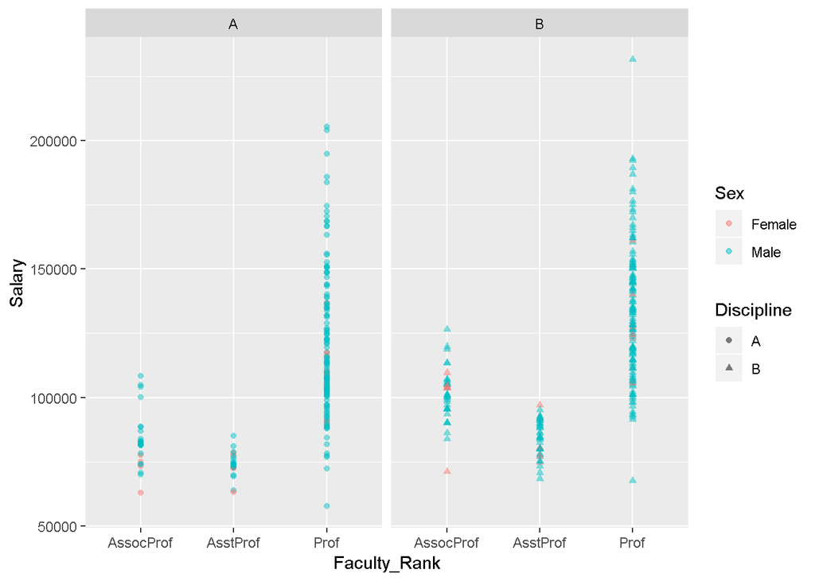

```r
#Relationship between salary and faculty rank, by sex and discipline
salary_yrs <- ggplot(faculty_salary, aes(x = Faculty_Rank, y = Salary)) +
  geom_point(aes(color = Sex, pch = Discipline), alpha = 0.5) +
  facet_wrap(~Discipline)

salary_yrs
```

## Linear regression model - Saturated (all variables)

```r
salary_lm1 <- lm(Salary ~ Discipline + Sex + Faculty_Rank + Years_Since_PhD + Years_Faculty_Service, data = faculty_salary)
summary(salary_lm1)
```

```
##
## Call:
## lm(formula = Salary ~ Discipline + Sex + Faculty_Rank + Years_Since_PhD +
##     Years_Faculty_Service, data = faculty_salary)
##
## Residuals:
##    Min     1Q Median     3Q    Max
## -65248 -13211  -1775  10384  99592
##
## Coefficients:
##                       Estimate Std. Error t value Pr(>|t|)
## (Intercept)            78862.8     4990.3  15.803  < 2e-16 ***
## DisciplineB            14417.6     2342.9   6.154 1.88e-09 ***
## SexMale                 4783.5     3858.7   1.240  0.21584
## Faculty_RankAsstProf  -12907.6     4145.3  -3.114  0.00198 **
## Faculty_RankProf       32158.4     3540.6   9.083  < 2e-16 ***
## Years_Since_PhD          535.1      241.0   2.220  0.02698 *
## Years_Faculty_Service   -489.5      211.9  -2.310  0.02143 *
## ---
## Signif. codes:  0 '***' 0.001 '**' 0.01 '*' 0.05 '.' 0.1 ' ' 1
##
## Residual standard error: 22540 on 390 degrees of freedom
## Multiple R-squared:  0.4547, Adjusted R-squared:  0.4463
## F-statistic:  54.2 on 6 and 390 DF,  p-value: < 2.2e-16
```

Salary = 78862.8 + 14417.6(Discipline B) + 4783.5(Sex Male) - 12907.6(AsstProf) + 32158.4(Prof) + 535.1(Years_Since_PhD) - 489.5 (Years_Faculty_Service)

Reference levels: Discipline A (0), Female (0), AssocProf (0)

But… this says that as you increase years of service, your salary decreases -> Might indicate collinearity

## Test for collinearity

```r
salary_simple <- faculty_salary %>%
  select(Salary, Years_Since_PhD, Years_Faculty_Service)

cor(salary_simple) #High correlation bw Years_Since_PhD and Years_Faculty_Service
```

```
##                          Salary Years_Since_PhD Years_Faculty_Service
## Salary                1.0000000       0.4192311             0.3347447
## Years_Since_PhD       0.4192311       1.0000000             0.9096491
## Years_Faculty_Service 0.3347447       0.9096491             1.0000000
```

```r
#VIF
vif(salary_lm1)
```

```
##                           GVIF Df GVIF^(1/(2*Df))
## Discipline            1.064105  1        1.031555
## Sex                   1.030805  1        1.015285
## Faculty_Rank          2.013193  2        1.191163
## Years_Since_PhD       7.518936  1        2.742068
## Years_Faculty_Service 5.923038  1        2.433729
```

High correlation bw Years_Since_PhD and Years_Faculty_Service: 0.91

VIF Years_Since_PhD: 7.51 Years_Faculty_Service: 5.92

So we should remove Years_Since_PhD or Years_Faculty_Service - which makes sense conceptually

## Linear regression model - subsets

```r
#Model without Years_Since_PhD
salary_lm2 <- lm(Salary ~ Discipline + Sex + Faculty_Rank + Years_Faculty_Service, data = faculty_salary)
summary(salary_lm2)
```

```
##
## Call:
## lm(formula = Salary ~ Discipline + Sex + Faculty_Rank + Years_Faculty_Service,
##     data = faculty_salary)
##
## Residuals:
##    Min     1Q Median     3Q    Max
## -64202 -14255  -1533  10571  99163
##
## Coefficients:
##                        Estimate Std. Error t value Pr(>|t|)
## (Intercept)            82912.07    4668.39  17.760  < 2e-16 ***
## DisciplineB            13473.38    2315.50   5.819 1.24e-08 ***
## SexMale                 4771.25    3878.00   1.230 0.219311
## Faculty_RankAsstProf  -14560.40    4098.32  -3.553 0.000428 ***
## Faculty_RankProf       34599.24    3382.52  10.229  < 2e-16 ***
## Years_Faculty_Service    -88.78     111.64  -0.795 0.426958
## ---
## Signif. codes:  0 '***' 0.001 '**' 0.01 '*' 0.05 '.' 0.1 ' ' 1
##
## Residual standard error: 22650 on 391 degrees of freedom
## Multiple R-squared:  0.4478, Adjusted R-squared:  0.4407
## F-statistic: 63.41 on 5 and 391 DF,  p-value: < 2.2e-16
```

```r
vif(salary_lm2)
```

```
##                           GVIF Df GVIF^(1/(2*Df))
## Discipline            1.029040  1        1.014416
## Sex                   1.030803  1        1.015284
## Faculty_Rank          1.597441  2        1.124233
## Years_Faculty_Service 1.627110  1        1.275582
```

```r
#Model without Years_Faculty_Service
salary_lm3 <- lm(Salary ~ Discipline + Sex + Faculty_Rank + Years_Since_PhD, data = faculty_salary)
summary(salary_lm3)
```

```
##
## Call:
## lm(formula = Salary ~ Discipline + Sex + Faculty_Rank + Years_Since_PhD,
##     data = faculty_salary)
##
## Residuals:
##    Min     1Q Median     3Q    Max
## -67451 -13860  -1549  10716  97023
##
## Coefficients:
##                       Estimate Std. Error t value Pr(>|t|)
## (Intercept)           80988.47    4931.84  16.422  < 2e-16 ***
## DisciplineB           13937.47    2346.53   5.940 6.32e-09 ***
## SexMale                4349.37    3875.39   1.122  0.26242
## Faculty_RankAsstProf -13104.15    4167.31  -3.145  0.00179 **
## Faculty_RankProf      32928.40    3544.40   9.290  < 2e-16 ***
## Years_Since_PhD          61.01     127.01   0.480  0.63124
## ---
## Signif. codes:  0 '***' 0.001 '**' 0.01 '*' 0.05 '.' 0.1 ' ' 1
##
## Residual standard error: 22660 on 391 degrees of freedom
## Multiple R-squared:  0.4472, Adjusted R-squared:  0.4401
## F-statistic: 63.27 on 5 and 391 DF,  p-value: < 2.2e-16
```

```r
vif(salary_lm3)
```

```
##                     GVIF Df GVIF^(1/(2*Df))
## Discipline      1.055727  1        1.027486
## Sex             1.028359  1        1.014080
## Faculty_Rank    1.987205  2        1.187301
## Years_Since_PhD 2.065517  1        1.437191
```

```r
#Model without Years_Since_PhD and Years_Faculty_Service
salary_lm4 <- lm(Salary ~ Discipline + Sex + Faculty_Rank, data = faculty_salary)
summary(salary_lm4)
```

```
##
## Call:
## lm(formula = Salary ~ Discipline + Sex + Faculty_Rank, data = faculty_salary)
##
## Residuals:
##    Min     1Q Median     3Q    Max
## -66268 -14127  -1566  10813  97718
##
## Coefficients:
##                      Estimate Std. Error t value Pr(>|t|)
## (Intercept)             81947       4506  18.187  < 2e-16 ***
## DisciplineB             13709       2295   5.972 5.25e-09 ***
## SexMale                  4492       3860   1.164 0.245291
## Faculty_RankAsstProf   -13723       3959  -3.466 0.000586 ***
## Faculty_RankProf        33680       3177  10.600  < 2e-16 ***
## ---
## Signif. codes:  0 '***' 0.001 '**' 0.01 '*' 0.05 '.' 0.1 ' ' 1
##
## Residual standard error: 22640 on 392 degrees of freedom
## Multiple R-squared:  0.4469, Adjusted R-squared:  0.4412
## F-statistic: 79.18 on 4 and 392 DF,  p-value: < 2.2e-16
```

```r
vif(salary_lm4)
```

```
##                  GVIF Df GVIF^(1/(2*Df))
## Discipline   1.012236  1        1.006099
## Sex          1.022339  1        1.011108
## Faculty_Rank 1.034437  2        1.008500
```

Model lm2 (Model without Years_Since_PhD): Salary = 82912.1 + 13473.4(Discipline B) + 4771.3(Sex Male) - 14560.4(AsstProf) + 34599.2(Prof) - 88.8 (Years_Faculty_Service)

Model lm3 (Model without Years_Faculty_Service): Salary = 80988.5 + 13937.5(Discipline B) + 4349.4(Sex Male) - 13104.2(AsstProf) + 32928.4(Prof) + 61.0 (Years_Since_PhD)

Model lm4: Salary = 81947 + 13709(Discipline B) + 4492(Sex Male) - 13723(AsstProf) + 33680(Prof)

## Interaction terms?

```r
salary_lm5 <- lm(Salary ~ Sex + Faculty_Rank + Discipline + Years_Faculty_Service + Discipline*Years_Faculty_Service, data = faculty_salary)

summary(salary_lm5)
```

```
##
## Call:
## lm(formula = Salary ~ Sex + Faculty_Rank + Discipline + Years_Faculty_Service +
##     Discipline * Years_Faculty_Service, data = faculty_salary)
##
## Residuals:
##    Min     1Q Median     3Q    Max
## -70632 -14191  -2098   9937  94331
##
## Coefficients:
##                                   Estimate Std. Error t value Pr(>|t|)
## (Intercept)                        86338.5     4880.9  17.689  < 2e-16 ***
## SexMale                             5196.1     3861.9   1.345 0.179254
## Faculty_RankAsstProf              -13899.7     4086.8  -3.401 0.000741 ***
## Faculty_RankProf                   34121.8     3371.0  10.122  < 2e-16 ***
## DisciplineB                         6255.7     3916.2   1.597 0.110989
## Years_Faculty_Service               -266.8      135.8  -1.965 0.050128 .
## DisciplineB:Years_Faculty_Service    406.3      178.3   2.279 0.023221 *
## ---
## Signif. codes:  0 '***' 0.001 '**' 0.01 '*' 0.05 '.' 0.1 ' ' 1
##
## Residual standard error: 22530 on 390 degrees of freedom
## Multiple R-squared:  0.455,  Adjusted R-squared:  0.4467
## F-statistic: 54.27 on 6 and 390 DF,  p-value: < 2.2e-16
```

```r
vif(salary_lm5)
```

```
##                                      GVIF Df GVIF^(1/(2*Df))
## Sex                              1.033210  1        1.016469
## Faculty_Rank                     1.625251  2        1.129094
## Discipline                       2.975161  1        1.724865
## Years_Faculty_Service            2.432170  1        1.559542
## Discipline:Years_Faculty_Service 3.484050  1        1.866561
```

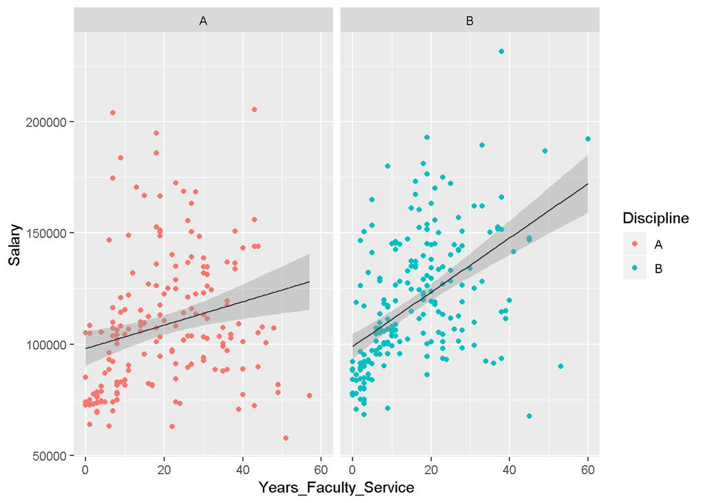

```r
#Relationship between salary and Years_Faculty_Service, by discipline
service_model <- lm(Salary ~ Years_Faculty_Service + Discipline, data = faculty_salary)

service_graph1 <- ggplot(faculty_salary, aes(x = Years_Faculty_Service, y = Salary))+
geom_point(aes(color = Discipline))+
  facet_wrap(~Discipline)+
  geom_smooth(method = lm, se = TRUE, size = 0.5, color = "gray20")
service_graph1
```

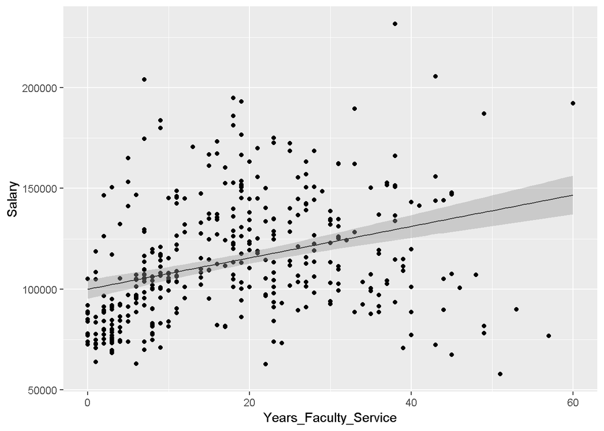

```r
service_graph2 <- ggplot(faculty_salary, aes(x = Years_Faculty_Service, y = Salary))+
geom_point()+
  geom_smooth(method = lm, se = TRUE, size = 0.5, color = "gray20")
service_graph2
```

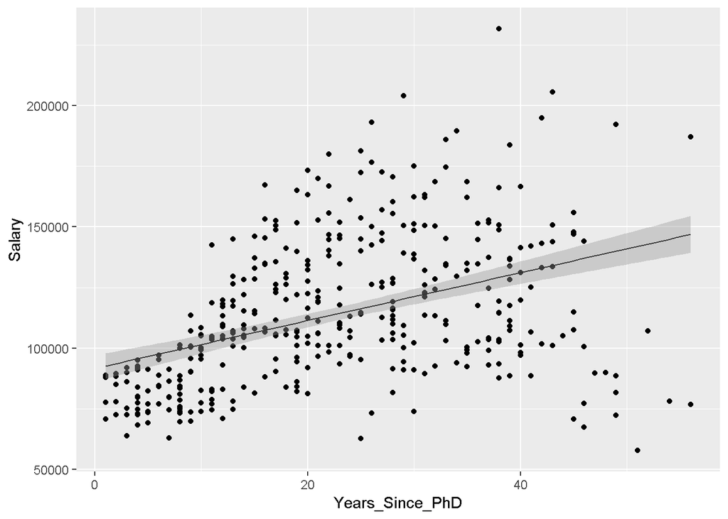

```r
service_graph3 <- ggplot(faculty_salary, aes(x = Years_Since_PhD, y = Salary))+
geom_point()+
  geom_smooth(method = lm, se = TRUE, size = 0.5, color = "gray20")
service_graph3
```

## Diagnostic plots

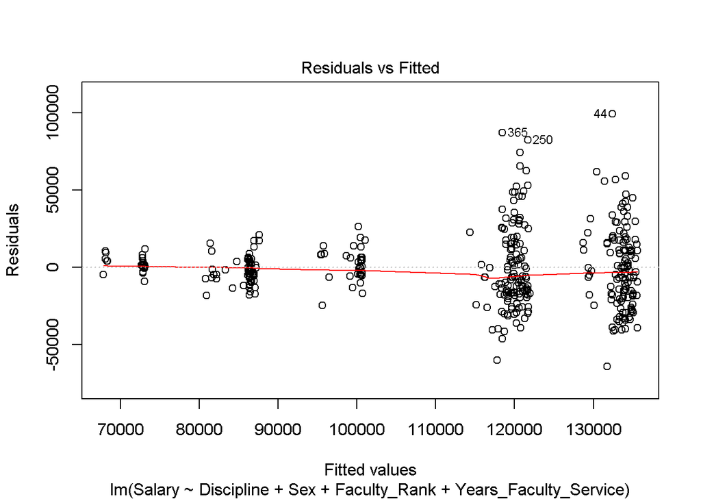

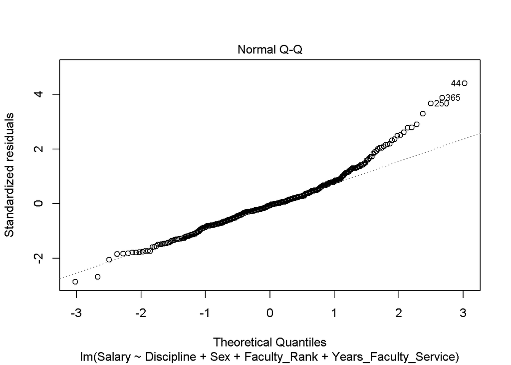

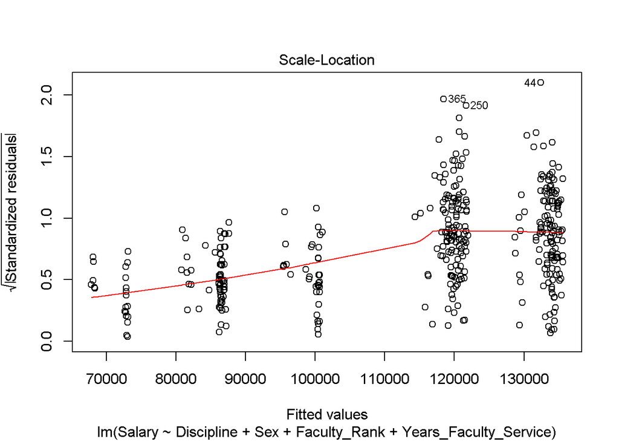

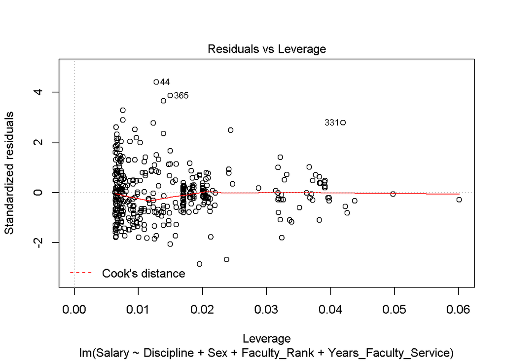

```r
plot(salary_lm2)
```

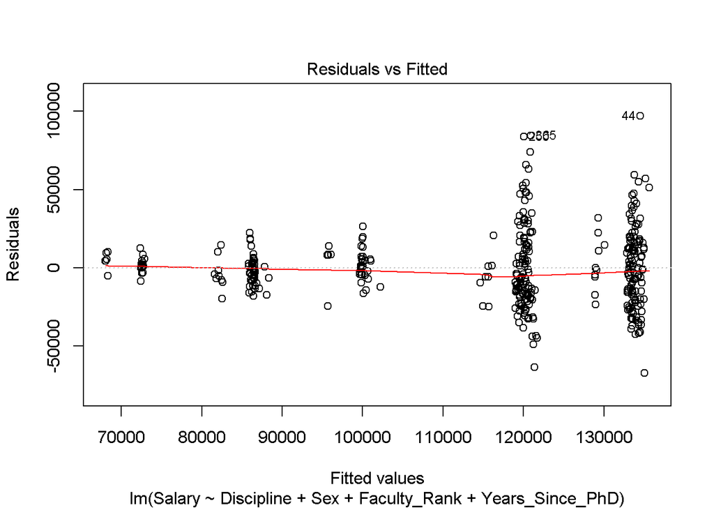

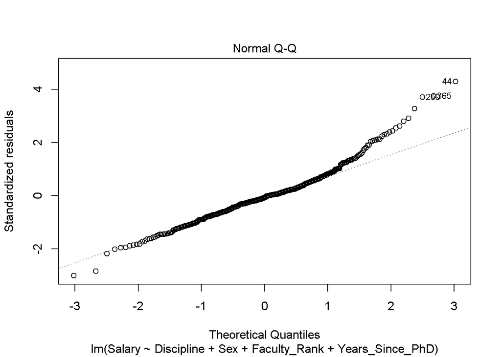

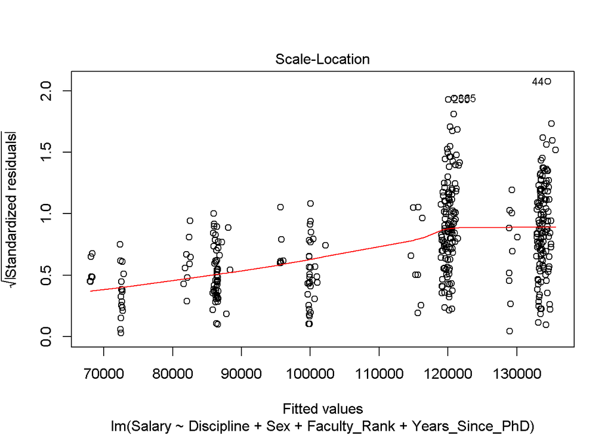

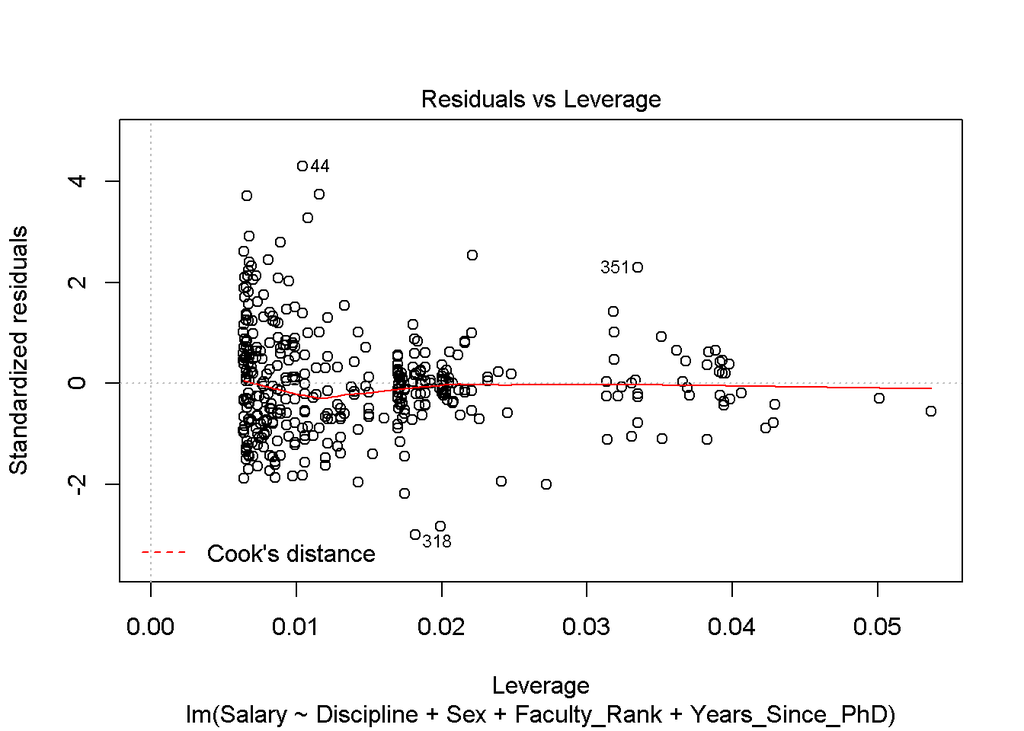

```r
plot(salary_lm3)
```

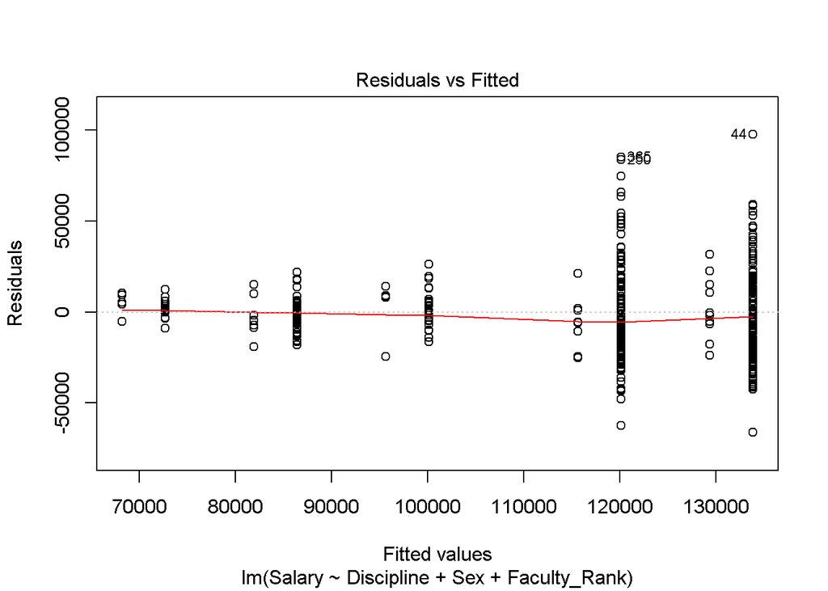

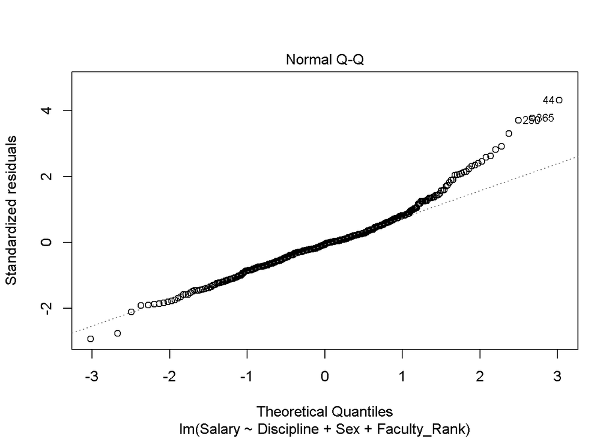

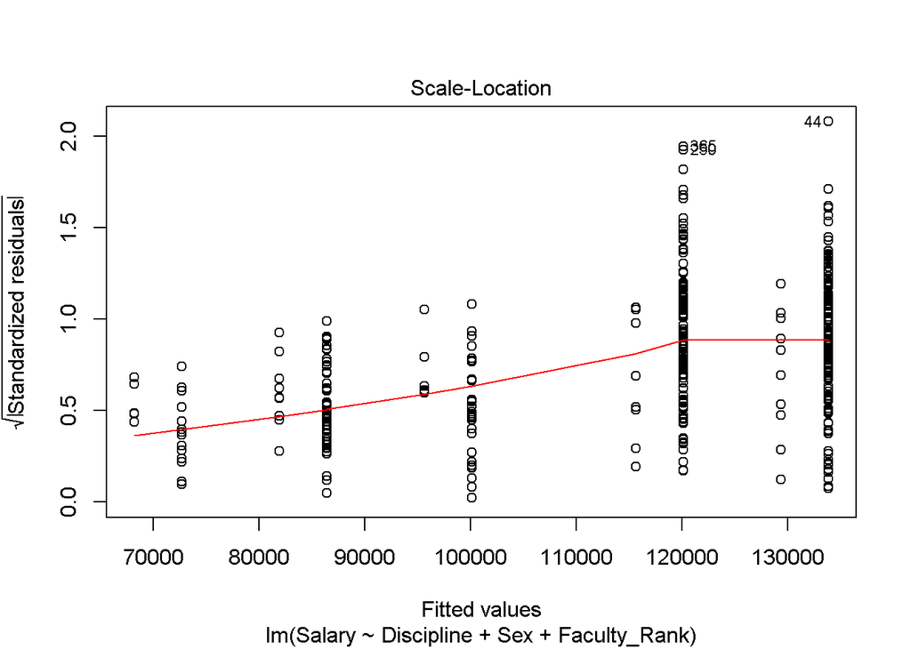

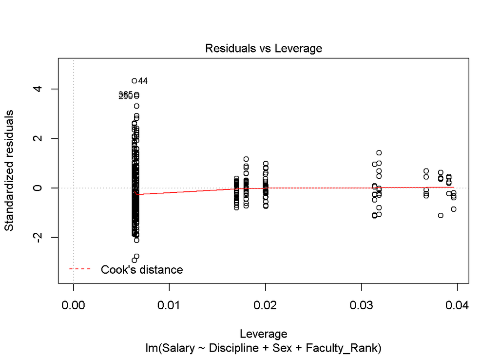

```r
plot(salary_lm4)
```